# Part 1 Homework

```r
R.version.string
```

```
## [1] "R version 3.4.2 (2017-09-28)"
```

```r
Sys.Date()
```

```
## [1] "2017-10-27"
```

```r
sleepdata <- "http://www.statsci.org/data/general/sleep.txt"
sleeptable <- read.table(file=sleepdata,header=TRUE)
head(sleeptable)
```

```
##                  Species   BodyWt BrainWt NonDreaming Dreaming TotalSleep
## 1        Africanelephant 6654.000  5712.0          NA       NA        3.3
## 2 Africangiantpouchedrat    1.000     6.6         6.3      2.0        8.3
## 3              ArcticFox    3.385    44.5          NA       NA       12.5
## 4   Arcticgroundsquirrel    0.920     5.7          NA       NA       16.5
## 5          Asianelephant 2547.000  4603.0         2.1      1.8        3.9
## 6                 Baboon   10.550   179.5         9.1      0.7        9.8
##   LifeSpan Gestation Predation Exposure Danger
## 1     38.6       645         3        5      3
## 2      4.5        42         3        1      3
## 3     14.0        60         1        1      1
## 4       NA        25         5        2      3
## 5     69.0       624         3        5      4
## 6     27.0       180         4        4      4
```

```r
tail(sleeptable)
```

```
##                 Species BodyWt BrainWt NonDreaming Dreaming TotalSleep
## 57               Tenrec  0.900     2.6        11.0      2.3       13.3
## 58            Treehyrax  2.000    12.3         4.9      0.5        5.4
## 59            Treeshrew  0.104     2.5        13.2      2.6       15.8
## 60               Vervet  4.190    58.0         9.7      0.6       10.3
## 61         Wateropossum  3.500     3.9        12.8      6.6       19.4
## 62 Yellow-belliedmarmot  4.050    17.0          NA       NA         NA
##    LifeSpan Gestation Predation Exposure Danger
## 57      4.5        60         2        1      2
## 58      7.5       200         3        1      3
## 59      2.3        46         3        2      2
## 60     24.0       210         4        3      4
## 61      3.0        14         2        1      1
## 62     13.0        38         3        1      1
```

1. Notice that there is a huge range in body weight. Display the information for the smallest and the largest mammals.

```r
summary(sleeptable$BodyWt)
```

```
##     Min.  1st Qu.   Median     Mean  3rd Qu.     Max.
##    0.005    0.600    3.342  198.790   48.203 6654.000
```

Min = .005 Max = 6654.00

```r
sleeptable[which(sleeptable$BodyWt==.005), ]
```

```
##                    Species BodyWt BrainWt NonDreaming Dreaming TotalSleep
## 32 Lessershort-tailedshrew  0.005    0.14         7.7      1.4        9.1
##    LifeSpan Gestation Predation Exposure Danger
## 32      2.6      21.5         5        2      4
```

```r
sleeptable[which(sleeptable$BodyWt==6654.00), ]
```

```
##           Species BodyWt BrainWt NonDreaming Dreaming TotalSleep LifeSpan
## 1 Africanelephant   6654    5712          NA       NA        3.3     38.6
##   Gestation Predation Exposure Danger
## 1       645         3        5      3
```

2. Which variables have missing data?

Variables with value of NA: NonDreaming, Dreaming, TotalSleep, LifeSpan, Gestation

3. Calculate the mean and standard deviation for TotalSleep. )

```r
mean(sleeptable$TotalSleep,na.rm = TRUE)
```

```
## [1] 10.53276
```

```r
sd(sleeptable$TotalSleep,na.rm = TRUE)
```

```
## [1] 4.60676
```

4. Draw a histogram for the BodyWt variable. Note that this variable is highly skewed. Re-draw the histogram on the log scale. Hint: log(sl$BodyWt,base=10). For exta credit, relabel the axes with values at 0.001, 0.01, etc.

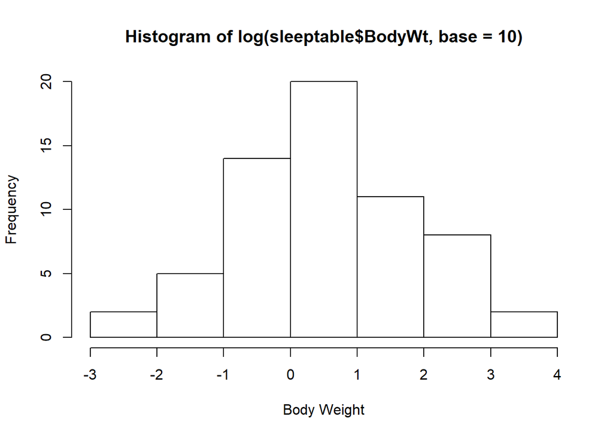

```r
hist(log(sleeptable$BodyWt,base=10),xlab = "Body Weight")
```

5. Calculate the ratio of BrainWt to BodyWt and express it as a percentage. Be sure to convert grams to kilograms (or vice versa) before computing the ratio. What animal has the smallest/largest ratio?

```r
sleeptable["BrainWt_BodyWt_Ratio"] <- (sleeptable$BrainWt/((sleeptable$BodyWt)*1000))*100
summary(sleeptable$BrainWt_BodyWt_Ratio)
```

```
##    Min. 1st Qu.  Median    Mean 3rd Qu.    Max.
## 0.08584 0.31026 0.66109 0.96242 1.36684 3.96040
```

```r
sleeptable[which.min(sleeptable$BrainWt_BodyWt_Ratio), ]
```

```
##           Species BodyWt BrainWt NonDreaming Dreaming TotalSleep LifeSpan
## 1 Africanelephant   6654    5712          NA       NA        3.3     38.6
##   Gestation Predation Exposure Danger BrainWt_BodyWt_Ratio
## 1       645         3        5      3            0.0858431
```

```r
sleeptable[which.max(sleeptable$BrainWt_BodyWt_Ratio), ]
```

```
##           Species BodyWt BrainWt NonDreaming Dreaming TotalSleep LifeSpan
## 27 Groundsquirrel  0.101       4        10.4      3.4       13.8        9
##    Gestation Predation Exposure Danger BrainWt_BodyWt_Ratio
## 27        28         5        1      3             3.960396
```

Smallest Ratio = Africanelephant Largest Ratio = Groundsquirrel

6. Do bigger animals sleep longer or live longer? Show your results using a correlation coefficient.

```r
round(100*cor(sleeptable[,-1],use = "pairwise.complete.obs"),2)
```

```
##                      BodyWt BrainWt NonDreaming Dreaming TotalSleep
## BodyWt               100.00   93.42      -37.59   -10.94     -30.72
## BrainWt               93.42  100.00      -36.92   -10.51     -35.81
## NonDreaming          -37.59  -36.92      100.00    51.43      96.27
## Dreaming             -10.94  -10.51       51.43   100.00      72.71
## TotalSleep           -30.72  -35.81       96.27    72.71     100.00
## LifeSpan              30.25   50.93      -38.44   -29.57     -41.02
## Gestation             65.11   74.72      -59.47   -45.09     -63.13
## Predation              5.95    3.39      -31.82   -44.75     -39.58
## Exposure              33.83   36.78      -54.38   -53.72     -64.23
## Danger                13.36   14.59      -48.39   -57.93     -58.77
## BrainWt_BodyWt_Ratio -20.67  -19.94       34.48    -5.68      25.74
##                      LifeSpan Gestation Predation Exposure Danger
## BodyWt                  30.25     65.11      5.95    33.83  13.36
## BrainWt                 50.93     74.72      3.39    36.78  14.59
## NonDreaming            -38.44    -59.47    -31.82   -54.38 -48.39
## Dreaming               -29.57    -45.09    -44.75   -53.72 -57.93
## TotalSleep             -41.02    -63.13    -39.58   -64.23 -58.77
## LifeSpan               100.00     61.48    -10.25    36.04   6.18
## Gestation               61.48    100.00     20.05    63.83  37.86
## Predation              -10.25     20.05    100.00    61.82  91.60
## Exposure                36.04     63.83     61.82   100.00  78.72
## Danger                   6.18     37.86     91.60    78.72 100.00
## BrainWt_BodyWt_Ratio   -11.91    -30.14     -9.08   -33.59 -21.64
##                      BrainWt_BodyWt_Ratio
## BodyWt                             -20.67
## BrainWt                            -19.94
## NonDreaming                         34.48
## Dreaming                            -5.68
## TotalSleep                          25.74
## LifeSpan                           -11.91
## Gestation                          -30.14
## Predation                           -9.08
## Exposure                           -33.59
## Danger                             -21.64
## BrainWt_BodyWt_Ratio               100.00
```

```
              TotalSleep LifeSpan
   BodyWt     -30.72    30.25
```

Bigger animals live longer. Positive correlation between lifespan and BodyWt

7. Do animals who have high degrees of Predation, Exposure, or Danger sleep less? Show your results using a plot and a trendline.

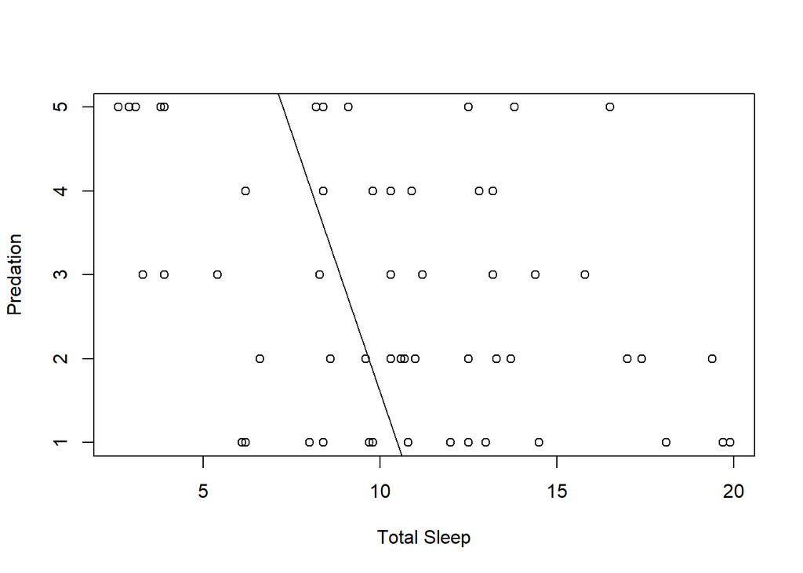

```r
plot(sleeptable$TotalSleep,sleeptable$Predation,xlab = "Total Sleep",ylab="Predation")
abline(lm(sleeptable$TotalSleep~sleeptable$Predation))
```

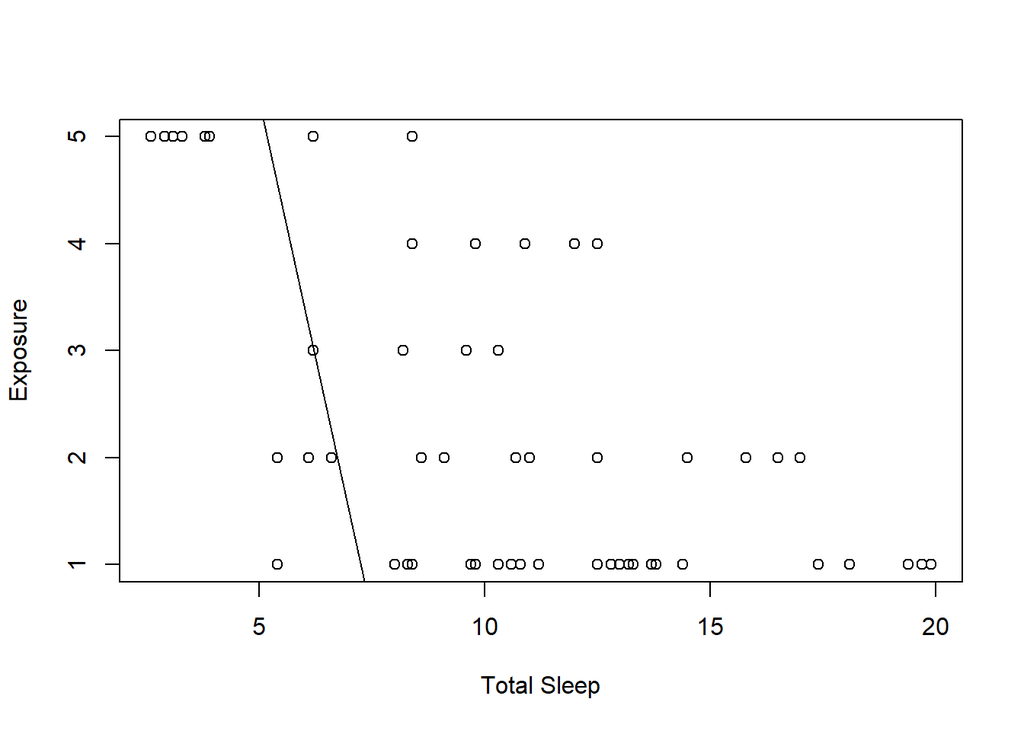

```r
plot(sleeptable$TotalSleep,sleeptable$Exposure,xlab = "Total Sleep",ylab="Exposure")
abline(lm(sleeptable$TotalSleep~sleeptable$Exposure))
```

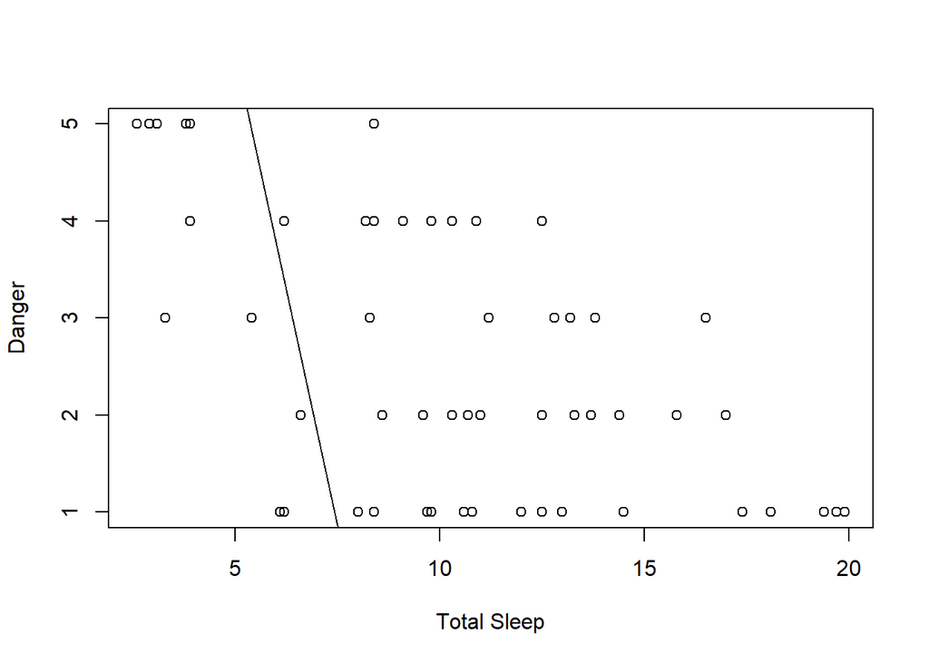

```r
plot(sleeptable$TotalSleep,sleeptable$Danger,xlab = "Total Sleep",ylab="Danger")
abline(lm(sleeptable$TotalSleep~sleeptable$Danger))
```

Yes, based on the trend line animals with a higher degree of Predation, Exposure, and Danger sleep less

8. Place all the key results into a Word document or PowerPoint presentation, or as a PDF file or as an HTML file. Turn it in by email. Use the subject line: “Introduction to R, (your name), Part 1 Homework”